# Association Project

Abdukholik_Tukhtamishev

2025-01-24

# About Dataset

The dataset used in this research was sourced from Kaggle to market basket analysis. It is structured such that each row represents a transaction, and each column represents a product. The dataset is binary-encoded, meaning that for any given transaction, a value of 1 indicates that a product was purchased, while a value of 0 signifies that the product was not bought. This format makes the dataset ideal for exploring customer purchasing behavior and identifying frequent itemsets.

# About my project

The primary objective of this research was to uncover frequent itemsets—combinations of products that are commonly purchased together by customers. Understanding these associations can provide valuable insights for businesses, such as designing effective product bundling strategies, optimizing store layouts, and improving marketing campaigns.

To analyze the dataset, two widely used algorithms for association rule mining were employed: Apriori and ECLAT. Both methods aim to identify frequent itemsets, but they differ in their approach:

The Apriori algorithm generates candidate itemsets iteratively and applies a support threshold to prune less frequent combinations. Additionally, Apriori can produce association rules that help understand the strength of relationships between products. The ECLAT algorithm, on the other hand, uses a depth-first search approach and focuses on vertical data representation to efficiently compute frequent itemsets.

The analysis aimed to compare these two methods in terms of:

1. The number of associations discovered: Determining which algorithm generates more frequent itemsets under the same conditions.
2. Efficiency and runtime: Evaluating the computational performance of both algorithms on the dataset.

Through this study, the frequent itemsets preferred by customers were identified, and the performance of the two algorithms was thoroughly compared to highlight their strengths and limitations. This comparison provides practical insights into the suitability of each method for different types of datasets and analytical requirements.

```r
# Libraries
library(tidyverse)
library(dplyr)
library(arules)
```

```r
library(arulesViz)
library(ggplot2)


# Working directory
setwd("E:/UWarsaw/unsupervised_learning/USL_Project/Association")
getwd()
```

```
## [1] "E:/UWarsaw/unsupervised_learning/USL_Project/Association"
```

```r
# Upload dataset
basket <- read.csv("E:/UWarsaw/unsupervised_learning/USL_Project/Association/market.csv")

# General Summary
head(basket)
```

```
##                                                                                                                                                     products
## 1 Bread;Honey;Bacon;Toothpaste;Banana;Apple;Hazelnut;Cheese;Meat;Carrot;Cucumber;Onion;Milk;Butter;ShavingFoam;Salt;Flour;HeavyCream;Egg;Olive;Shampoo;Sugar
## 2                                                                                                                1;0;1;0;1;1;1;0;0;1;0;0;0;0;0;0;0;1;1;0;0;1
## 3                                                                                                                1;1;1;0;1;1;1;0;0;0;1;0;1;1;0;0;1;0;0;1;1;0
## 4                                                                                                                0;1;1;1;1;1;1;1;1;0;1;1;1;0;1;1;1;1;1;0;0;1
## 5                                                                                                                1;1;0;1;0;1;0;0;0;0;1;1;1;0;0;0;1;0;1;1;1;0
## 6                                                                                                                0;1;0;0;0;0;0;0;0;0;0;0;0;0;0;0;0;0;0;0;0;0
```

```r
dim(basket)
```

```
## [1] 465   1
```

```r
colSums(is.na(basket))
```

```
## products
##        0
```

As usual, once dataset has been uploaded, general structure of the dataset is analyzed and data cleaning procedure takes place

```r
# Separate
basket_sep <- basket %>%
  separate(products, sep = ";", into = c("Bread", "Honey",
                                         "Bacon", "Toothpaste",
                                         "Banana", "Apple",
                                         "Hazelnut", "Cheese",
                                         "Meat", "Carrot",
                                         "Cucumber", "Onion",
                                         "Milk", "Butter",
                                         "ShavingFoam", "Salt",
                                         "Flour", "HeavyCream",
                                         "Egg", "Olive",
                                         "Shampoo", "Sugar"))
head(basket_sep)
```

```
##   Bread Honey Bacon Toothpaste Banana Apple Hazelnut Cheese Meat Carrot
## 1 Bread Honey Bacon Toothpaste Banana Apple Hazelnut Cheese Meat Carrot
## 2     1     0     1          0      1     1        1      0    0      1
## 3     1     1     1          0      1     1        1      0    0      0
## 4     0     1     1          1      1     1        1      1    1      0
## 5     1     1     0          1      0     1        0      0    0      0
## 6     0     1     0          0      0     0        0      0    0      0
##   Cucumber Onion Milk Butter ShavingFoam Salt Flour HeavyCream Egg Olive
## 1 Cucumber Onion Milk Butter ShavingFoam Salt Flour HeavyCream Egg Olive
## 2        0     0    0      0           0    0     0          1   1     0
## 3        1     0    1      1           0    0     1          0   0     1
## 4        1     1    1      0           1    1     1          1   1     0
## 5        1     1    1      0           0    0     1          0   1     1
## 6        0     0    0      0           0    0     0          0   0     0
##   Shampoo Sugar
## 1 Shampoo Sugar
## 2       0     1
## 3       1     0
## 4       0     1
## 5       1     0
## 6       0     0
```

```r
# Removing the row with product name
basket_sep <- basket_sep[-1, ]
head(basket_sep)
```

```
##   Bread Honey Bacon Toothpaste Banana Apple Hazelnut Cheese Meat Carrot
## 2     1     0     1          0      1     1        1      0    0      1
## 3     1     1     1          0      1     1        1      0    0      0
## 4     0     1     1          1      1     1        1      1    1      0
## 5     1     1     0          1      0     1        0      0    0      0
## 6     0     1     0          0      0     0        0      0    0      0
## 7     0     1     0          1      0     0        1      0    0      0
##   Cucumber Onion Milk Butter ShavingFoam Salt Flour HeavyCream Egg Olive
## 2        0     0    0      0           0    0     0          1   1     0
## 3        1     0    1      1           0    0     1          0   0     1
## 4        1     1    1      0           1    1     1          1   1     0
## 5        1     1    1      0           0    0     1          0   1     1
## 6        0     0    0      0           0    0     0          0   0     0
## 7        0     1    0      0           1    0     0          0   0     0
##   Shampoo Sugar
## 2       0     1
## 3       1     0
## 4       0     1
## 5       1     0
## 6       0     0
## 7       0     1
```

```r
# Converting to transaction format
# Converting binary matrix to a list of transactions
transactions <- apply(basket_sep, 1, function(row) {
  colnames(basket_sep)[row == 1]  # Select column names where value is 1
})

# Convert the list into a transactions object
transactions <- as(transactions, "transactions")

# View summary of transactions
summary(transactions)
```

```
## transactions as itemMatrix in sparse format with
##  464 rows (elements/itemsets/transactions) and
##  22 columns (items) and a density of 0.3993926
##
## most frequent items:
##     Banana     Cheese      Bacon   Hazelnut HeavyCream    (Other)
##        208        206        200        195        193       3075
##
## element (itemset/transaction) length distribution:
## sizes
##  1  2  3  4  5  6  7  8  9 10 11 12 13 14 15 16 17
## 19 22 11 30 33 28 25 35 37 45 42 43 41 27 18  5  3
##
##    Min. 1st Qu.  Median    Mean 3rd Qu.    Max.
##   1.000   6.000   9.000   8.787  12.000  17.000
##
## includes extended item information - examples:
##   labels
## 1  Apple
## 2  Bacon
## 3 Banana
##
## includes extended transaction information - examples:
##   transactionID
## 1             2
## 2             3
## 3             4
```

```r
inspect(transactions[1:5])  # Inspect first 5 transactions
```

```
##     items          transactionID
## [1] {Apple,
##      Bacon,
##      Banana,
##      Bread,
##      Carrot,
##      Egg,
##      Hazelnut,
##      HeavyCream,
##      Sugar}                    2
## [2] {Apple,
##      Bacon,
##      Banana,
##      Bread,
##      Butter,
##      Cucumber,
##      Flour,
##      Hazelnut,
##      Honey,
##      Milk,
##      Olive,
##      Shampoo}                  3
## [3] {Apple,
##      Bacon,
##      Banana,
##      Cheese,
##      Cucumber,
##      Egg,
##      Flour,
##      Hazelnut,
##      HeavyCream,
##      Honey,
##      Meat,
##      Milk,
##      Onion,
##      Salt,
##      ShavingFoam,
##      Sugar,
##      Toothpaste}               4
## [4] {Apple,
##      Bread,
##      Cucumber,
##      Egg,
##      Flour,
##      Honey,
##      Milk,
##      Olive,
##      Onion,
##      Shampoo,
##      Toothpaste}               5
## [5] {Honey}                    6
```

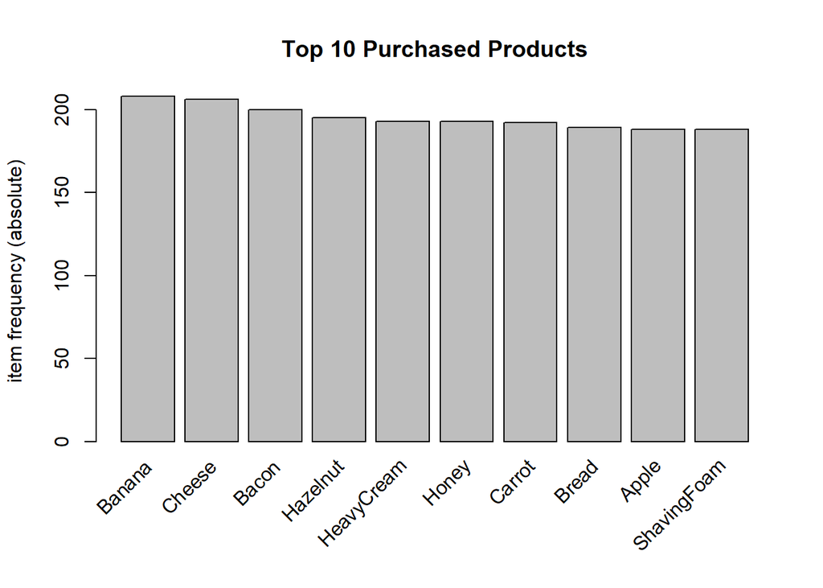

```r
# Plot item frequency (Top 10 products)
itemFrequencyPlot(transactions, topN = 10, type = "absolute", main = "Top 10 Purchased Products")
```

Binary matrix data has been converted to list of transactions after which summary and inspection carried out on list of transactions. Bar plot of top 10 products has also been included in order to have a better visual demonstration. It turns out that banana, cheese, and bacon are the top selling groceries.

```r
# Apriori algorithm
rules_apriori <- apriori(transactions, parameter = list(supp = 0.01, conf = 0.5))
```

```
## Apriori
##
## Parameter specification:
##  confidence minval smax arem  aval originalSupport maxtime support minlen
##         0.5    0.1    1 none FALSE            TRUE       5    0.01      1
##  maxlen target  ext
##      10  rules TRUE
##
## Algorithmic control:
##  filter tree heap memopt load sort verbose
##     0.1 TRUE TRUE  FALSE TRUE    2    TRUE
##
## Absolute minimum support count: 4
##
## set item appearances ...[0 item(s)] done [0.00s].
## set transactions ...[22 item(s), 464 transaction(s)] done [0.00s].
## sorting and recoding items ... [22 item(s)] done [0.00s].
## creating transaction tree ... done [0.00s].
## checking subsets of size 1 2 3 4 5 6 7 8 9 10
```

```
##  done [0.07s].
## writing ... [468212 rule(s)] done [0.15s].
## creating S4 object  ... done [0.27s].
```

```r
summary(rules_apriori)
```

```
## set of 468212 rules
##
## rule length distribution (lhs + rhs):sizes
##      2      3      4      5      6      7      8      9     10
##     65   1970  15337  73698 206198 142182  26579   2133     50
##
##    Min. 1st Qu.  Median    Mean 3rd Qu.    Max.
##   2.000   6.000   6.000   6.195   7.000  10.000
##
## summary of quality measures:
##     support          confidence        coverage            lift
##  Min.   :0.01078   Min.   :0.5000   Min.   :0.01078   Min.   :1.115
##  1st Qu.:0.01078   1st Qu.:0.5556   1st Qu.:0.01724   1st Qu.:1.388
##  Median :0.01293   Median :0.6250   Median :0.02155   Median :1.568
##  Mean   :0.01719   Mean   :0.6583   Mean   :0.02757   Mean   :1.632
##  3rd Qu.:0.01940   3rd Qu.:0.7222   3rd Qu.:0.03017   3rd Qu.:1.820
##  Max.   :0.24138   Max.   :1.0000   Max.   :0.44828   Max.   :2.729
##      count
##  Min.   :  5.000
##  1st Qu.:  5.000
##  Median :  6.000
##  Mean   :  7.977
##  3rd Qu.:  9.000
##  Max.   :112.000
##
## mining info:
##          data ntransactions support confidence
##  transactions           464    0.01        0.5
##                                                                     call
##  apriori(data = transactions, parameter = list(supp = 0.01, conf = 0.5))
```

```r
# Inspect top 10-Rules
inspect(sort(rules_apriori, by = "lift")[1:10])
```

```
##      lhs                                      rhs       support    confidence
## [1]  {Bread, Butter, Flour, Milk, Olive}   => {Shampoo} 0.01508621 1
## [2]  {Bread, Flour, Milk, Olive, Onion}    => {Shampoo} 0.01077586 1
## [3]  {Apple, Bread, Flour, Milk, Olive}    => {Shampoo} 0.01077586 1
## [4]  {Apple, Bacon, Flour, Milk, Olive}    => {Shampoo} 0.01077586 1
## [5]  {Bacon, Flour, Milk, Olive, Salt}     => {Shampoo} 0.01077586 1
## [6]  {Bacon, Egg, Flour, Milk, Olive}      => {Shampoo} 0.01077586 1
## [7]  {Bacon, Flour, Hazelnut, Milk, Olive} => {Shampoo} 0.01939655 1
## [8]  {Bacon, Cheese, Flour, Milk, Olive}   => {Shampoo} 0.01077586 1
## [9]  {Apple, Bread, Flour, Hazelnut, Milk} => {Shampoo} 0.01077586 1
## [10] {Butter, Milk, Olive, Salt, Sugar}    => {Shampoo} 0.01724138 1
##      coverage   lift     count
## [1]  0.01508621 2.729412 7
## [2]  0.01077586 2.729412 5
## [3]  0.01077586 2.729412 5
## [4]  0.01077586 2.729412 5
## [5]  0.01077586 2.729412 5
## [6]  0.01077586 2.729412 5
## [7]  0.01939655 2.729412 9
## [8]  0.01077586 2.729412 5
## [9]  0.01077586 2.729412 5
## [10] 0.01724138 2.729412 8
```

```r
# Keep only the top 100 rules by lift
top_rules <- head(sort(rules_apriori, by = "lift"), 100)
```

These results highlight clear purchasing patterns, with certain items frequently co-occurring in transactions. While the analysis provided meaningful insights, the dataset’s small size and the potential focus on niche groups (low-support rules) may limit broader applicability.

```
## To reduce overplotting, jitter is added! Use jitter = 0 to prevent jitter.
```

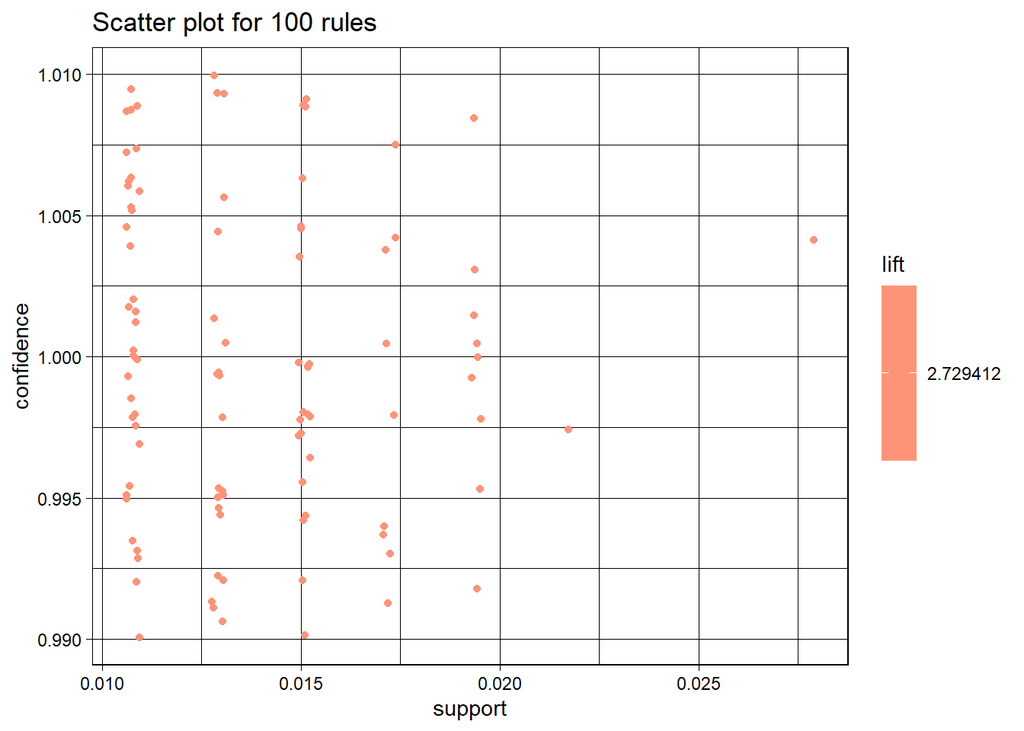

```r
# Keep only the top 100 rules by lift
top_rules <- head(sort(rules_apriori, by = "lift"), 100)

# Plot the top-rule set
plot(top_rules, method = "scatterplot", measure = c("support", "confidence"), shading = "lift")
```

This scatter plot displays the top 100 rules derived from your Apriori analysis, sorted by lift, showcasing each rule with its corresponding support and confidence.

Support: Values primarily range between 1% and 2.5%, indicating these rules, while infrequent, are significant.

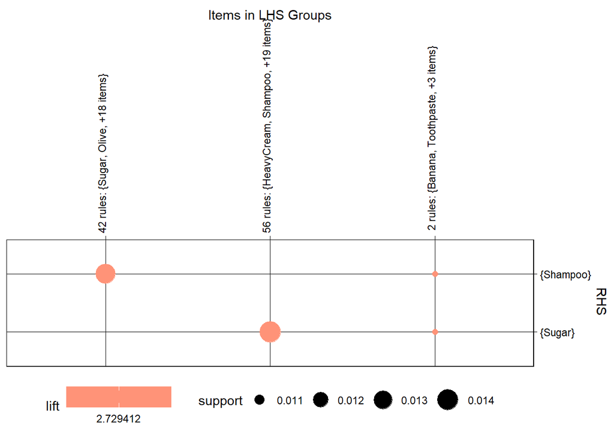

```r
# Grouped matrix plot
plot(top_rules, method = "grouped")
```

This grouped matrix plot visualizes specific association rules from analysis, focusing on the relationships between items in the left-hand side (LHS) and right-hand side (RHS) groups of the rules.

Observations:

**RHS Items**: The y-axis shows items found in the RHS of these rules, such as `{Shampoo}` and `{Sugar}`, highlighting what items are likely to be purchased with the LHS groups.

**Support Values**: Points are plotted with varying sizes based on the support metric. Larger points indicate a higher frequency of the rule in the dataset.

Conclusion:

This plot categorizes rules into groups based on common LHS items, helping to clarify which combinations of products are commonly purchased together with specific other products. It is particularly useful for identifying potential cross-sell opportunities or for enhancing product placement strategies in retail settings.

```r
# Graph-Based Visualization
plot(top_rules, method = "graph", engine = "htmlwidget")
```

[interactive chart not shown]

[output not shown]

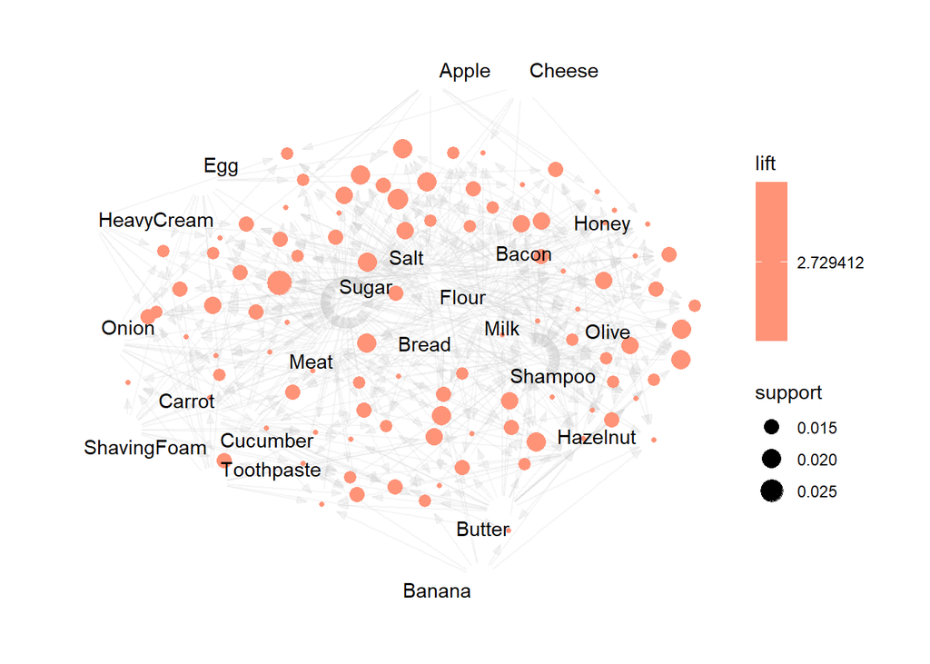

```r
plot(top_rules, method = "graph", control = list(type = "items"))
```

The graph-based visualization depicts the relationships between different items based on association rules derived from your data, showing how various items are interconnected.

Observations:

**Nodes**: Each node in the graph represents an item from dataset, such as “Apple,” “Cheese,” “Egg,” etc.

**Edges**: The lines connecting the nodes represent association rules, indicating that the connected items are frequently bought together.

Conclusion:

This visualization provides a clear and interactive way to understand the complex relationships between items based on rule analysis. It helps identify key items that serve as hubs in the network, suggesting they are central in various purchasing combinations. This can inform strategies for product placement, promotions, and inventory management in a retail context.

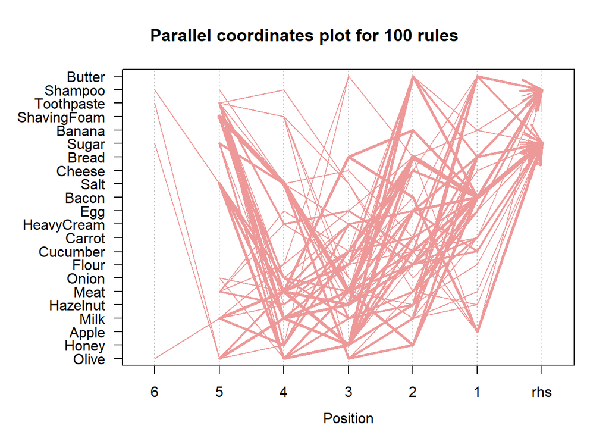

```r
# Parallel coordinates plot
plot(top_rules, method = "paracoord", control = list(reorder = TRUE))
```

The parallel coordinates plot presents the association rules involving various items, helping to visualize the relationships and dependencies between items across the rules.

Observations:

**Lines**: Each line represents an association rule, extending across various dimensions (positions) that correspond to items in the rules.

**Density of Lines**: Areas with a high density of lines suggest common item combinations across multiple rules. For example, if many lines intersect at the positions for “Milk” and “Bread,” it indicates that these two items frequently appear together in the rules.

Conclusion:

This visualization is useful for identifying common patterns and relationships within the data. For instance, frequent intersections at certain items can pinpoint key products that often appear together, suggesting strong market basket affinities. This can aid in marketing strategies like bundle promotions or targeted advertising.

```r
# ECLAT
# Applying Eclat to find frequent itemsets
frequent_itemsets <- eclat(transactions, parameter = list(supp = 0.01, maxlen = 3))
```

```
## Eclat
##
## parameter specification:
##  tidLists support minlen maxlen            target  ext
##     FALSE    0.01      1      3 frequent itemsets TRUE
##
## algorithmic control:
##  sparse sort verbose
##       7   -2    TRUE
##
## Absolute minimum support count: 4
##
## create itemset ...
## set transactions ...[22 item(s), 464 transaction(s)] done [0.00s].
## sorting and recoding items ... [22 item(s)] done [0.00s].
## creating bit matrix ... [22 row(s), 464 column(s)] done [0.00s].
## writing  ... [1793 set(s)] done [0.00s].
## Creating S4 object  ... done [0.00s].
```

```r
# Inspecting the frequent itemsets
inspect(frequent_itemsets)
```

```
##        items                                 support    count
## [1]    {Banana, Milk, Shampoo}               0.06034483  28
## [2]    {Cheese, Milk, Shampoo}               0.06896552  32
## [3]    {Bacon, Milk, Shampoo}                0.08189655  38
## [4]    {Hazelnut, Milk, Shampoo}             0.08405172  39
## [5]    {HeavyCream, Milk, Shampoo}           0.07758621  36
## [6]    {Honey, Milk, Shampoo}                0.08189655  38
## [7]    {Carrot, Milk, Shampoo}               0.06681034  31
## [8]    {Egg, Milk, Shampoo}                  0.07758621  36
## [9]    {Milk, Shampoo, ShavingFoam}          0.04956897  23
## [10]   {Bread, Milk, Shampoo}                0.07758621  36
## [11]   {Milk, Shampoo, Toothpaste}           0.06896552  32
## [12]   {Milk, Salt, Shampoo}                 0.06034483  28
## [13]   {Apple, Milk, Shampoo}                0.07327586  34
## [14]   {Meat, Milk, Shampoo}                 0.06896552  32
```

[output cut: 1779 more lines]

```r
# Sorting frequent itemsets
sorted_itemsets <- sort(frequent_itemsets, by = "support", decreasing = TRUE)
inspect(sorted_itemsets)
```

```
##        items                                 support    count
## [1]    {Banana}                              0.44827586 208
## [2]    {Cheese}                              0.44396552 206
## [3]    {Bacon}                               0.43103448 200
## [4]    {Hazelnut}                            0.42025862 195
## [5]    {HeavyCream}                          0.41594828 193
## [6]    {Honey}                               0.41594828 193
## [7]    {Carrot}                              0.41379310 192
## [8]    {Bread}                               0.40732759 189
## [9]    {ShavingFoam}                         0.40517241 188
## [10]   {Apple}                               0.40517241 188
## [11]   {Egg}                                 0.40301724 187
## [12]   {Salt}                                0.39870690 185
## [13]   {Meat}                                0.38793103 180
## [14]   {Flour}                               0.38577586 179
```

[output cut: 1779 more lines]

```r
# Top 10 itemsets
top_10 <- head(sorted_itemsets)
inspect(top_10)
```

```
##     items        support   count
## [1] {Banana}     0.4482759 208
## [2] {Cheese}     0.4439655 206
## [3] {Bacon}      0.4310345 200
## [4] {Hazelnut}   0.4202586 195
## [5] {HeavyCream} 0.4159483 193
## [6] {Honey}      0.4159483 193
```

```r
# Frequent itemsets with exactly 3 items
triple_itemsets <- frequent_itemsets[size(frequent_itemsets) == 3]

# Sorting by support
sorted_triple_itemsets <- sort(triple_itemsets, by = "support", decreasing = TRUE)

# Selecting the top 10 triple itemsets
top_triple_itemsets <- head(sorted_triple_itemsets, 10)
```

The ECLAT algorithm was applied to analyze the dataset with a minimum support threshold of 1% and a maximum itemset length of 3. This configuration was designed to efficiently identify frequent itemsets while keeping the complexity manageable. The algorithm processed 22 unique items across 464 transactions, producing 1,793 frequent itemsets. To narrow the focus to the most relevant results, frequent itemsets with exactly 3 items were extracted and sorted by support. From these, the top 10 triple itemsets with the highest support values were selected for further analysis.

The ECLAT algorithm’s vertical data representation and depth-first search approach enabled efficient identification of these patterns. The results provide actionable insights into customer purchasing behavior, particularly for targeting promotions or bundling products frequently bought together. Compared to Apriori, ECLAT does not generate association rules but excels at quickly identifying frequent itemsets, making it particularly suitable for this type of analysis.

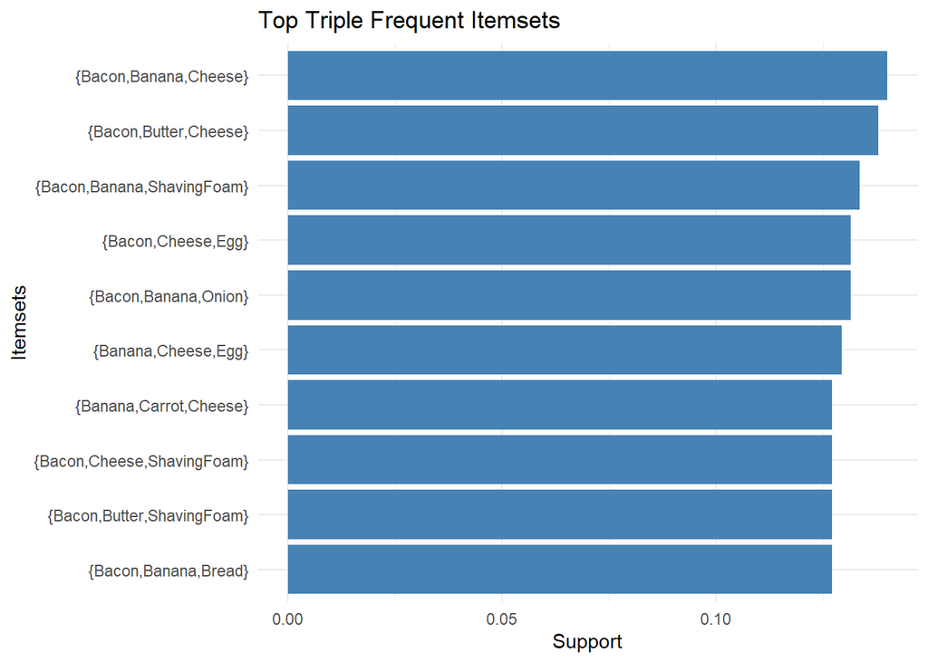

```r
# Visuals
# Plotting a bar chart for the top triple itemsets
top_triple_df <- as(top_triple_itemsets, "data.frame")
ggplot(top_triple_df, aes(x = reorder(items, support), y = support)) +
  geom_bar(stat = "identity", fill = "steelblue") +
  coord_flip() +
  labs(
    title = "Top Triple Frequent Itemsets",
    x = "Itemsets",
    y = "Support"
  ) +
  theme_minimal()
```

This bar chart displays the support values for the top triple frequent itemsets derived from association rule mining analysis.

Key Points:

**Itemsets**: Each bar represents a combination of three items. For example, the top bar corresponds to the itemset {Bacon, Banana, Cheese}, indicating that these three items are frequently bought together.

**Support**: The length of each bar shows the support value, which measures how often the itemset appears in the dataset relative to all transactions. Higher bars represent itemsets that occur more frequently.

**Visualization**: The bars are ordered from highest to lowest support, making it easy to see which triple item combinations are most common in your data.

Conclusion:

This chart is useful for quickly identifying which combinations of three items are most popular among customers, helping informed product bundling, placement, and promotional strategies.

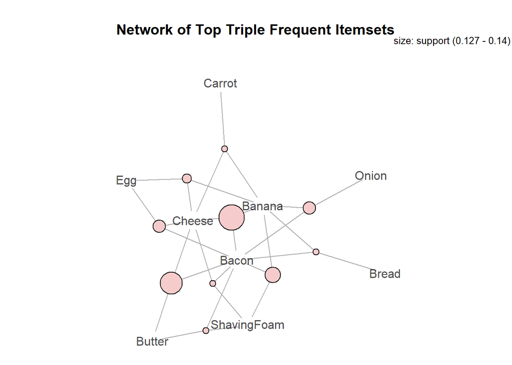

```r
# Network plot
plot(top_triple_itemsets, method = "graph", engine = "igraph",
     main = "Network of Top Triple Frequent Itemsets")
```

This network visualization depicts the relationships between various items based on the top triple frequent itemsets from data.

Key Features:

**Nodes**: Each node represents an item, such as Bacon, Banana, or Cheese.

**Edges**: The lines connecting the nodes represent itemsets where the connected items appear together frequently.

**Layout**: The spatial arrangement helps to identify which items are most central in the network, suggesting their higher connectivity and importance in the itemsets.

Conclusion:

This network plot is useful for visualizing complex relationships in a simple form, allowing to quickly see which items frequently co-occur in transactions. It’s particularly helpful for identifying potential focal points for marketing strategies or product placement optimizations in retail settings.

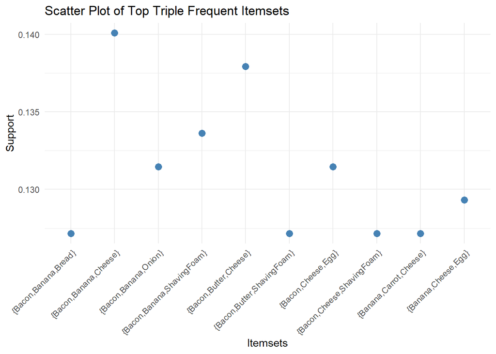

```r
# Scatter plot
ggplot(top_triple_df, aes(x = items, y = support)) +
  geom_point(color = "steelblue", size = 3) +
  labs(title = "Scatter Plot of Top Triple Frequent Itemsets", x = "Itemsets", y = "Support") +
  theme_minimal() +
  theme(axis.text.x = element_text(angle = 45, hjust = 1)) # Rotate x-axis labels
```

This scatter plot illustrates the support values for the top triple frequent itemsets in dataset.

Key Points:

**X-Axis (Itemsets)**: Each point on the x-axis represents a unique triple itemset, such as `{Bacon, Banana, Cheese}` or `{Bacon, Butter, Cheese}`.

**Y-Axis (Support)**: The y-axis reflects the support values, showing the frequency of each itemset in the dataset.

**Visualization**: The points are evenly distributed, with clear labels for each itemset. The tilted x-axis labels ensure better readability.

Conclusion:

This scatter plot effectively highlights the relative support of different triple itemsets, helping to compare their popularity. It’s a clean and simple way to visualize which combinations are more frequently purchased, aiding in decision-making for promotions or product bundling.

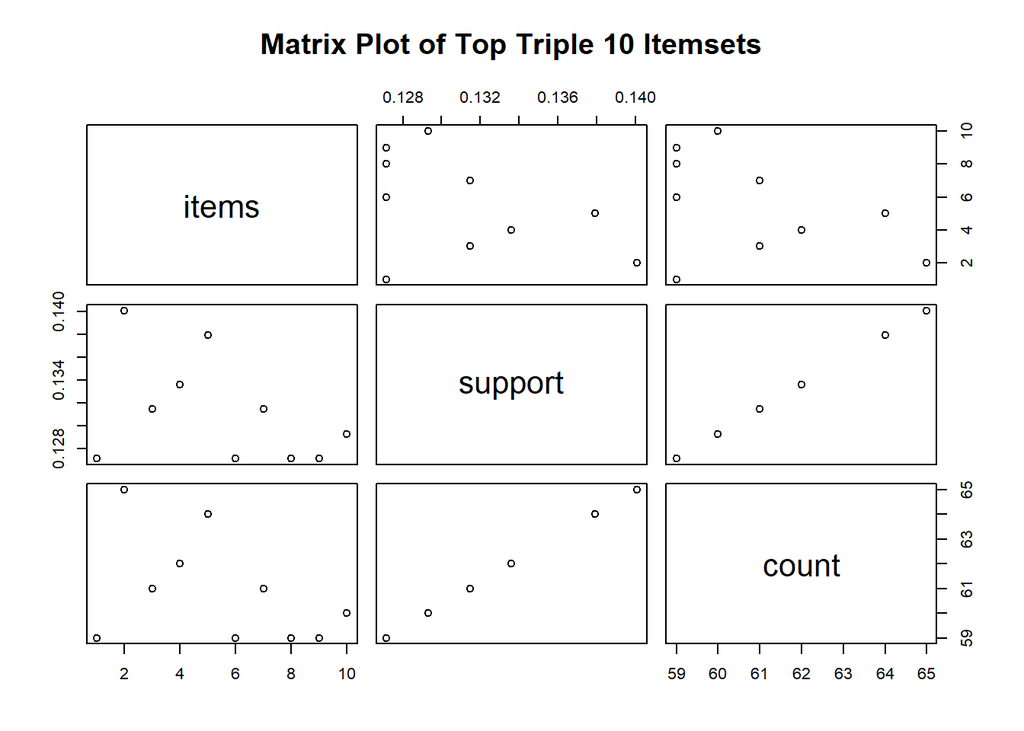

```r
# Matrix plot
plot(top_triple_df, method = "matrix",
     main = "Matrix Plot of Top Triple 10 Itemsets")
```

The Matrix Plot visualizes the support values for the top 10 triple itemsets in dataset across various metrics such as item details, support levels, and counts.

Overview:

This matrix plot offers a multi-faceted view of the itemsets, providing insights not only into how often they appear but also giving a broader perspective on their relative importance and frequency within the dataset. Each panel contributes to a comprehensive analysis, enabling quick comparisons and assessments of the itemsets’ impact and relevance.

```r
# Comparing two methods
# For Apriori
length(rules_apriori)
```

```
## [1] 468212
```

```r
# For Eclat
length(frequent_itemsets)
```

```
## [1] 1793
```

```r
# Overlap
# Extracting itemsets from Apriori
apriori_itemsets <- unique(items(rules_apriori))

# Extracting itemsets from ECLAT
eclat_itemsets_list <- unique(items(frequent_itemsets))

# Comparing overlap
overlap <- intersect(apriori_itemsets, eclat_itemsets_list)
length(overlap)  # Number of overlapping itemsets
```

```
## [1] 1112
```

```r
# Comparing performance
# Apriori timing
time_apriori <- system.time({
  rules_apriori <- apriori(transactions,
                           parameter = list(supp = 0.01, conf = 0.6, maxlen = 8))
})
```

```
## Apriori
##
## Parameter specification:
##  confidence minval smax arem  aval originalSupport maxtime support minlen
##         0.6    0.1    1 none FALSE            TRUE       5    0.01      1
##  maxlen target  ext
##       8  rules TRUE
##
## Algorithmic control:
##  filter tree heap memopt load sort verbose
##     0.1 TRUE TRUE  FALSE TRUE    2    TRUE
##
## Absolute minimum support count: 4
##
## set item appearances ...[0 item(s)] done [0.00s].
## set transactions ...[22 item(s), 464 transaction(s)] done [0.00s].
## sorting and recoding items ... [22 item(s)] done [0.00s].
## creating transaction tree ... done [0.00s].
## checking subsets of size 1 2 3 4 5 6 7 8
```

```
##  done [0.08s].
## writing ... [295076 rule(s)] done [0.09s].
## creating S4 object  ... done [0.17s].
```

```r
print(time_apriori)
```

```
##    user  system elapsed
##    0.56    0.14    0.77
```

```r
# Eclat timing
time_eclat <- system.time({
  frequent_itemsets <- eclat(transactions,
                          parameter = list(supp = 0.01, maxlen = 8))
})
```

```
## Eclat
##
## parameter specification:
##  tidLists support minlen maxlen            target  ext
##     FALSE    0.01      1      8 frequent itemsets TRUE
##
## algorithmic control:
##  sparse sort verbose
##       7   -2    TRUE
##
## Absolute minimum support count: 4
##
## create itemset ...
## set transactions ...[22 item(s), 464 transaction(s)] done [0.00s].
## sorting and recoding items ... [22 item(s)] done [0.00s].
## creating bit matrix ... [22 row(s), 464 column(s)] done [0.00s].
## writing  ... [103938 set(s)] done [0.04s].
## Creating S4 object  ... done [0.06s].
```

```r
print(time_eclat)
```

```
##    user  system elapsed
##    0.12    0.02    0.15
```

```r
# Comparing timing of two methods
cat("Apriori runtime: ", time_apriori["elapsed"], "seconds\n")
```

```
## Apriori runtime:  0.77 seconds
```

```r
cat("ECLAT runtime: ", time_eclat["elapsed"], "seconds\n")
```

```
## ECLAT runtime:  0.15 seconds
```

### Conclusion

Throughout this project, I utilized the Apriori and ECLAT algorithms to analyze purchasing behaviors in a market basket dataset sourced from Kaggle. The primary goal was to uncover frequent itemsets that represent common combinations of products purchased together, offering valuable insights for strategic business applications such as product bundling, store layout optimization, and targeted marketing campaigns.

Key Findings:

**Frequent Itemsets**: Both Apriori and ECLAT successfully identified significant frequent itemsets, with Apriori extending its analysis to derive robust association rules that quantify the strength of these relationships through confidence and lift metrics.

**Algorithm Comparison**: The analysis demonstrated that while Apriori provides detailed insights into the relationships between items with the ability to filter by confidence and lift, ECLAT excels in efficiency, particularly noted in its faster runtime and focused identification of frequent itemsets.

**Top Products**: The analysis highlighted that certain items, such as bananas, cheese, and bacon, frequently appear as top-selling products, underscoring their importance in the purchasing patterns of customers.

Practical Implications:

The insights derived from this study are instrumental for retail managers and marketers in making informed decisions that could enhance customer satisfaction and business profitability. Specifically, understanding which items are frequently purchased together allows for:

**Effective Product Placement**: Strategic placement of complementary products can enhance the shopping experience and increase sales.

**Promotional Strategies**: Tailored promotions involving frequently bought together items can boost sales across less popular products.

**Inventory Management**: Better prediction of stock levels based on itemset popularity can reduce overstock and understock situations.

Algorithm Suitability:

**Apriori’s Rule-Based Insights**: Ideal for scenarios where understanding the interaction between products is crucial, such as in crafting targeted marketing messages or recommendations.

**ECLAT’s Speed**: Best suited for large datasets where quick identification of frequent itemsets is necessary, potentially in real-time scenarios.

Concluding Thoughts:

This research not only sheds light on the purchasing behaviors embedded within the dataset but also contrasts the practical utility of two pivotal algorithms in data mining. The findings encourage the adoption of a hybrid approach, leveraging the strengths of both Apriori and ECLAT to foster a deeper understanding and application of association rule mining in business contexts. Moving forward, incorporating additional data, such as seasonal variations and customer demographics, could further refine the analysis, enabling more personalized and dynamic marketing strategies.

## Authors

1. DION H. GOH
2. REBECCA P. ANG

*Nanyang Technological University, Singapore*

## [*An introduction to association rule mining: An application in counseling and help-seeking*](https://link.springer.com/content/pdf/10.3758/BF03193156.pdf)

## Key findings from the literature

Here are the key findings from your paper on association rule mining:

1. **Introduction and Methodology**:

The paper introduces Association Rule Mining (ARM) as a technique to discover relationships among a large set of variables. ARM was primarily utilized in the business sector but is adaptable to social sciences, including education and counseling.

2. **Applications of ARM**:

ARM is used in various fields such as market basket analysis, where it helps in understanding buying habits by identifying items frequently purchased together. This insight is valuable for arranging store layouts and promoting sales.

The application extends to various industries including medical diagnosis, marketing, sales, and now, social sciences where it is less commonly used.

3. **Comparison between Apriori and ECLAT**:

Apriori algorithm generates candidate itemsets iteratively and uses a support threshold to filter out less frequent itemsets. It also produces rules which help understand the strength of relationships between products.

ECLAT algorithm uses a depth-first search method focusing on vertical data representation, making it efficient for computing frequent itemsets.

4. **Results from Applying ARM**:

The research provided insights into frequent itemsets preferred by customers and highlighted the computational efficiency and effectiveness of both algorithms. It found that different algorithms might be more suited to different types of datasets based on the specific requirements of the analysis.

5. **Practical Insights**:

The comparison of ARM methods revealed practical insights into the suitability of each algorithm for different analytical needs. This can guide businesses or researchers in selecting the appropriate method depending on their specific data characteristics and analysis goals.

6. **General Conclusion**:

ARM is a valuable tool in uncovering hidden patterns and relationships in large datasets, which can be leveraged to optimize business strategies and improve decision-making processes. While both Apriori and ECLAT have their strengths, their applicability can vary based on the dataset and the specific needs of the analysis.